# Test_a_perceptual_phenomenon

Statistics: The Science of Decisions Project Instructions

Background Information

In a Stroop task, participants are presented with a list of words, with each word displayed in a color of ink. The participant’s task is to say out loud the color of the ink in which the word is printed. The task has two conditions: a congruent words condition, and an incongruent words condition. In the congruent words condition, the words being displayed are color words whose names match the colors in which they are printed: for example RED, BLUE. In the incongruent words condition, the words displayed are color words whose names do not match the colors in which they are printed: for example PURPLE, ORANGE. In each case, we measure the time it takes to name the ink colors in equally-sized lists. Each participant will go through and record a time from each condition. Questions For Investigation

As a general note, be sure to keep a record of any resources that you use or refer to in the creation of your project. You will need to report your sources as part of the project submission.

1. What is our independent variable? What is our dependent variable?
2. What is an appropriate set of hypotheses for this task? What kind of statistical test do you expect to perform? Justify your choices. Now it’s your chance to try out the Stroop task for yourself. Go to this link, which has a Java-based applet for performing the Stroop task. Record the times that you received on the task (you do not need to submit your times to the site.) Now, download this dataset which contains results from a number of participants in the task. Each row of the dataset contains the performance for one participant, with the first number their results on the congruent task and the second number their performance on the incongruent task.
3. Report some descriptive statistics regarding this dataset. Include at least one measure of central tendency and at least one measure of variability.
4. Provide one or two visualizations that show the distribution of the sample data. Write one or two sentences noting what you observe about the plot or plots.
5. Now, perform the statistical test and report your results. What is your confidence level and your critical statistic value? Do you reject the null hypothesis or fail to reject it? Come to a conclusion in terms of the experiment task. Did the results match up with your expectations?
6. Optional: What do you think is responsible for the effects observed? Can you think of an alternative or similar task that would result in a similar effect? Some research about the problem will be helpful for thinking about these two questions!

#### Load the data

```python
import pandas as pd
import numpy as np
import os
```

```python
os.getcwd()
```

```
'/Users/thuy/Documents/Statistics'
```

```python
ls
```

```
Data_Analyst_ND_Project0.ipynb      README.md                           Untitled.ipynb
Paired t test.Rmd                   Test_a_perceptual_phenomenon.ipynb  stroopdata.csv
```

```python
data = 'stroopdata.csv'
stroop_data = pd.read_csv(data)
```

```python
stroop_data
```

|  | Congruent | Incongruent |
| --- | --- | --- |
| 0 | 12.079 | 19.278 |
| 1 | 16.791 | 18.741 |
| 2 | 9.564 | 21.214 |
| 3 | 8.630 | 15.687 |
| 4 | 14.669 | 22.803 |
| 5 | 12.238 | 20.878 |
| 6 | 14.692 | 24.572 |
| 7 | 8.987 | 17.394 |
| 8 | 9.401 | 20.762 |
| 9 | 14.480 | 26.282 |
| 10 | 22.328 | 24.524 |
| 11 | 15.298 | 18.644 |
| 12 | 15.073 | 17.510 |
| 13 | 16.929 | 20.330 |
| 14 | 18.200 | 35.255 |
| 15 | 12.130 | 22.158 |
| 16 | 18.495 | 25.139 |
| 17 | 10.639 | 20.429 |
| 18 | 11.344 | 17.425 |
| 19 | 12.369 | 34.288 |
| 20 | 12.944 | 23.894 |
| 21 | 14.233 | 17.960 |
| 22 | 19.710 | 22.058 |
| 23 | 16.004 | 21.157 |

#### 1. What is our independent variable? What is our dependent variable?

Independent variable is was whether the word name and font color were the same (congruent words) or different (incongruent words).

Dependent variable is the time it takes to name the ink colors in equally-sized lists of congruent and incongruent words.

#### 2. What is an appropriate set of hypotheses for this task? What kind of statistical test do you expect to perform? Justify your choices.

The data has two set of samples and we do not know population parameters such as mean and variance. Therefore, t-test is the best statistical test assuming the data was random sampled and normal distributed. Since our participants were measured at two time points we use paired t-test for two related samples.

We could use two tail paired t-test for this task. However, given the information that in the incougruent words conditions the participants had to say out loud the color of the words that doesn't match its ink color. It seems harder job. My test results were: 10.39s and 20.85s for congruent and incongruent, respectively. So, we use one tail paired t-test for this task with the following hypotheses:

Ho = The mean times to name the ink colors in equally-sized lists of words are the same at an alpha of .05.

Ha = The mean time to name the ink colors in equally-sized lists of congruent words are less than incongruent words at an alpha of .05.

#### 3. Report some descriptive statistics regarding this dataset. Include at least one measure of central tendency and at least one measure of variability.

```python
stroop_data.describe()
```

|  | Congruent | Incongruent |
| --- | --- | --- |
| count | 24.000000 | 24.000000 |
| mean | 14.051125 | 22.015917 |
| std | 3.559358 | 4.797057 |
| min | 8.630000 | 15.687000 |
| 25% | 11.895250 | 18.716750 |
| 50% | 14.356500 | 21.017500 |
| 75% | 16.200750 | 24.051500 |
| max | 22.328000 | 35.255000 |

There was 24 participants in the two tests. In the congruent words conditions, the range of data was from 8.63 to 22.33, the mean was 14.05 and the standard deviation (std) was 3.56. In the incongruent words conditions, the range of the data was from 15.69 to 35.26, the mean was 22.02 and standard deviation (std) was 4.80. The descriptive statistics supported our hypotheses.

#### 4. Provide one or two visualizations that show the distribution of the sample data. Write one or two sentences noting what you observe about the plot or plots.

Our assumption for the t-test was the data was normal distributed. In order to test the assumption, we used histogram and fitting curve to show the shapes of the data together with quantile-quantile plots and Shapiro-Wilk tests. The results were below.

```python
# Distribution plot with fitting curve
%matplotlib inline
import matplotlib.pyplot as plt
import scipy.stats as stats
# can set bin by using , bins=np.arange(min(data), max(data) + binwidth, binwidth)
h = sorted(stroop_data['Congruent'])
def dis_plot(h):
    fit = stats.norm.pdf(h, np.mean(h), np.std(h))  #this is a fitting
    plt.plot(h,fit,'-o')
    plt.hist(h,normed=True)      #use this to draw histogram of your data
    plt.xlabel('Time')
    plt.ylabel('Percentage of Participants')
    plt.show()
# Reference: http://stackoverflow.com/questions/20011494/plot-normal-distribution-with-matplotlib
```

##### 4.1 Distribution of Congruent Data:

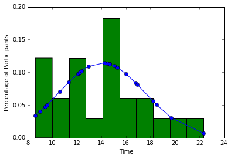

```python
h_con = sorted(stroop_data['Congruent'])
dis_plot(h_con)
```

We could see that the data of congruent test was almost normal distributed with the bell shape.

```python
import scipy
import scipy.stats as stats
scipy.stats.shapiro(data['Congruent']) # Test if the data is normal distribution using Shapiro-Wilk test
```

```
(0.970922589302063, 0.689803421497345)
```

The p value of Shapiro-Wilk test was 0.69 which was bigger than alpha of .05. So, we accepted the null that the data of cougruent test was normal distributed. The q-q plots also supported the results with the coefficient of determination was 0.98.

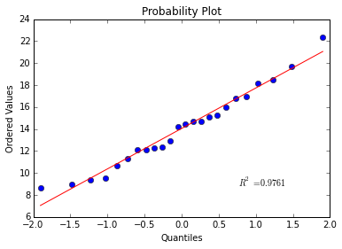

```python
import pylab
stats.probplot(data['Congruent'], dist="norm", plot=pylab) # Test if data is normal distribution using q-q plots
pylab.show()
# Reference http://stackoverflow.com/questions/13865596/quantile-quantile-plot-using-scipy
```

##### 4.2 Distribution of Incongruent Data:

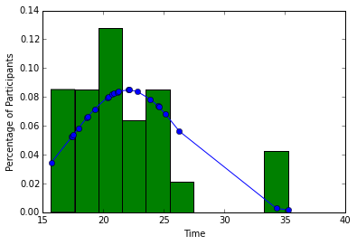

```python
h_incon = sorted(stroop_data['Incongruent'])
dis_plot(h_incon)
```

The data of incongruent test is also almost normal distributed, except two data had about 3 standard deviation above the mean which sketch the distribution to the right.

```python
import scipy.stats as stats
scipy.stats.shapiro(data['Incongruent']) # Test if the data is normal distribution using Shapiro-Wilk test
```

```
(0.85394686460495, 0.0025900385808199644)
```

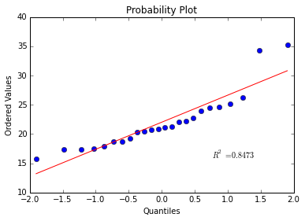

```python
import pylab
stats.probplot(data['Incongruent'], dist="norm", plot=pylab) # Test if data is normal distribution using q-q plots
pylab.show()
```

#### 5. Now, perform the statistical test and report your results. What is your confidence level and your critical statistic value? Do you reject the null hypothesis or fail to reject it? Come to a conclusion in terms of the experiment task. Did the results match up with your expectations?

```python
data = stroop_data
#t critical value = -1.714 at 95% confidence # one tailed t-test at df = 23
def t_CI(data):
    mean_dif = (data['Congruent'] - data['Incongruent']).mean()
    std_dif = (data['Congruent'] - data['Incongruent']).std()
    se = std_dif/np.sqrt(24) # standard of error
    t = mean_dif/se # t value
    print t
    print mean_dif
    CI = mean_dif + 1.714*se #Confidence interval
    print CI
```

```python
t_CI(stroop_data)
```

```
-8.02070694411
-7.96479166667
-6.26274058666
```

```python
# Double check results with Welch's t-Test
import scipy.stats
scipy.stats.ttest_rel(data['Congruent'], data['Incongruent'])
# p value of our test is p result divides by 2 since our t-test is one tail.
```

```
(-8.020706944109957, 4.1030005857111781e-08)
```

The t statistic value was -8.021, p value was 2.052e-08, true mean difference was -7.96 and confidence interval was [-inf , -6.26]

```python
# calculate the size effect Cohen'd
d = -8.02071/np.sqrt(23)
d
```

```
-1.6724336459717202
```

t(23) = -8.02, p <.005, d = -1.67 The t statistic value was -8.021 was less than t critical value of -1.714. The p value of 2.052e-08 was smaller than 0.05. Therefore, we could reject the null hypothesis. We can conclude that the time it takes to name the ink colors of congruent words was statiscally significant less than in incongruent words conditions. The results matched up with our expectations.

#### 6. Optional: What do you think is responsible for the effects observed? Can you think of an alternative or similar task that would result in a similar effect? Some research about the problem will be helpful for thinking about these two questions!

When the participants only had to read the words which names match the colors, their brains only need to work on reading the word and say out loud. Meanwhile, when they had to read the words which names does not match the colors, they have to say out loud the color without be interfered with the meaning of the words. The second task leads to more mistakes and longer time to achieve.

Another interesting example about how our brain works is a game call "Follow my instructions". Test person tells participants to do something like "Put your hand on your shoulder!" but the test person put her hand on her head. Many people just see it and do the same as the test person while they are supposed to do what she says. However, there are few people who focus on what she says will do much better. Our brain works quicker with automate reading and automate seeing but slower with interpretating their meaning to us. In order to make our brain works effectively, we need to filter distractions and pay attention to our goals.

#### References:

https://www.udacity.com/course/viewer#!/c-ud134-nd/l-4446458586/e-4435975018/m-4494178547

http://stackoverflow.com/questions/20011494/plot-normal-distribution-with-matplotlib

http://stackoverflow.com/questions/13865596/quantile-quantile-plot-using-scipy

http://docs.scipy.org/doc/scipy-0.15.1/reference/generated/scipy.stats.ttest_rel.html